# Survey, Experience & Participation Codebook

### Charting the Google Trends search interest

**What this does:** Draws the search-interest charts from the numbers above — interest over time, by base, by month, and the Ranch vs. Florida Sea Base. Saves `google_trends_analysis.png`.

**What to change:** Nothing required to re-run.

```python
# ═══════════════════════════════════════════════════════════════
# CELL 9c: GOOGLE TRENDS VISUALIZATIONS FROM HARD CODED
# ═══════════════════════════════════════════════════════════════

fig, axes = plt.subplots(2, 2, figsize=(16, 12))
fig.suptitle('Q6a: Google Search Interest — High Adventure Bases (2020-2025)',
             fontsize=14, fontweight='bold')

# ── Chart 1: Annual search interest over time (line chart) ───
for col in search_terms:
    axes[0,0].plot(df_annual.index, df_annual[col], marker='o', label=col, linewidth=2)
axes[0,0].set_title('Annual Search Interest Over Time (US)')
axes[0,0].set_ylabel('Avg Search Interest (0-100)')
axes[0,0].set_xlabel('Year')
axes[0,0].set_xticks(df_annual.index)
axes[0,0].legend(fontsize=8)
axes[0,0].axvline(2022, color='gray', linestyle='--', alpha=0.5)
axes[0,0].annotate('the Ranch peak\n(2022)',
                   xy=(2022, 48.3),
                   xytext=(2022.1, 42),
                   fontsize=8, color='gray',
                   arrowprops=dict(arrowstyle='->', color='gray', alpha=0.6))

# ── Chart 2: Annual averages bar chart ───────────────────────
x = range(len(df_annual))
width = 0.2
colors_bars = ['steelblue', 'coral', 'mediumseagreen', 'orange']
for i, col in enumerate(search_terms):
    axes[0,1].bar([xi + i*width for xi in x], df_annual[col],
                  width=width, label=col, color=colors_bars[i])
axes[0,1].set_title('Annual Search Interest by Base')
axes[0,1].set_ylabel('Avg Search Interest (0-100)')
axes[0,1].set_xticks([xi + width for xi in x])
axes[0,1].set_xticklabels(df_annual.index)
axes[0,1].legend(fontsize=8)

# ── Chart 3: Monthly seasonality for the Ranch ────────────────
month_labels = ['Jan','Feb','Mar','Apr','May','Jun',
                'Jul','Aug','Sep','Oct','Nov','Dec']
monthly_values = [df_monthly[m] for m in range(1,13)]
colors_monthly = ['gold' if m in [5,6,7] else 'steelblue' for m in range(1,13)]
axes[1,0].bar(month_labels, monthly_values, color=colors_monthly)
axes[1,0].set_title('the Ranch Search Interest by Month\n(gold = peak season May-Jul)')
axes[1,0].set_ylabel('Avg Search Interest (0-100)')
axes[1,0].set_xlabel('Month')

# ── Chart 4: Southeast regional comparison ───────────────────
southeast_states = df_southeast.index.tolist()
x_se = range(len(southeast_states))
width_se = 0.35
axes[1,1].bar([xi - width_se/2 for xi in x_se],
              df_southeast['the Ranch'],
              width_se, label='the Ranch', color='steelblue')
axes[1,1].bar([xi + width_se/2 for xi in x_se],
              df_southeast['Florida Sea Base'],
              width_se, label='Florida Sea Base', color='coral')
axes[1,1].set_title('the Ranch vs Florida Sea Base\n(Southeast States)')
axes[1,1].set_ylabel('Relative Search Interest (0-100)')
axes[1,1].set_xticks(list(x_se))
axes[1,1].set_xticklabels(southeast_states, rotation=15, ha='right', fontsize=8)
axes[1,1].legend(fontsize=8)
axes[1,1].annotate('Closest competition\nanywhere nationally',
                   xy=(0, 44),
                   xytext=(0.5, 55),
                   fontsize=8, color='red',
                   arrowprops=dict(arrowstyle='->', color='red', alpha=0.6))

plt.tight_layout()
plt.savefig('google_trends_analysis.png', dpi=150, bbox_inches='tight')
plt.show()
print("✅ Google Trends visualization saved")
```

```
[chart removed for de-identification — see notes]
```

```
✅ Google Trends visualization saved
```

## All the final presentation charts in one place

**What this does:** This is the "polished pictures for the slides" step. It redraws the cleanest version of each main chart and saves them all as image files (`q1_response_bias.png`, `q2_pain_pride.png`, `q3_return_rate.png`, `q4_nps_drivers.png`, `q5_camp_ratings.png`, `q6a_brand_awareness.png`, `q6a_barriers.png`). These are the images you drop straight into a slide deck.

**What to change:** If you want different titles on the slide images, edit the titles inside quotes here.

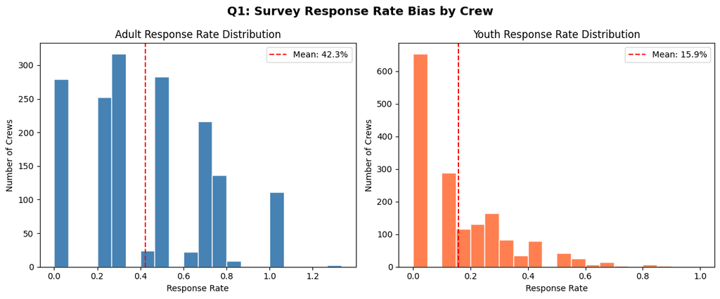

```
✅ Q1 chart saved
```

```
[chart removed for de-identification — see notes]
```

```
✅ Q2 chart saved
```

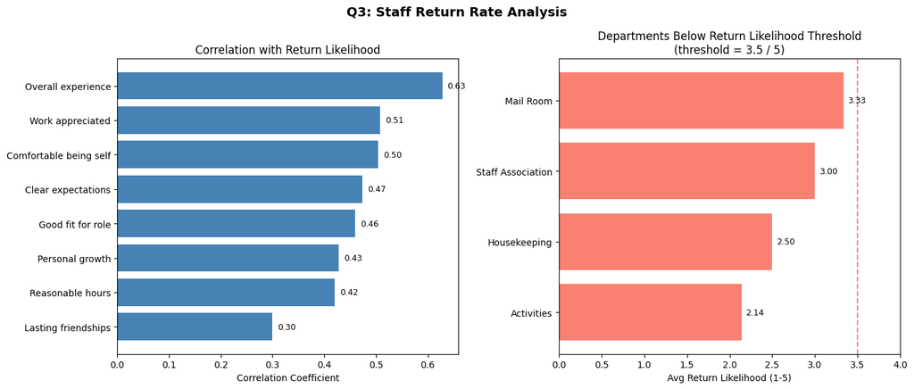

```
✅ Q3 chart saved
```

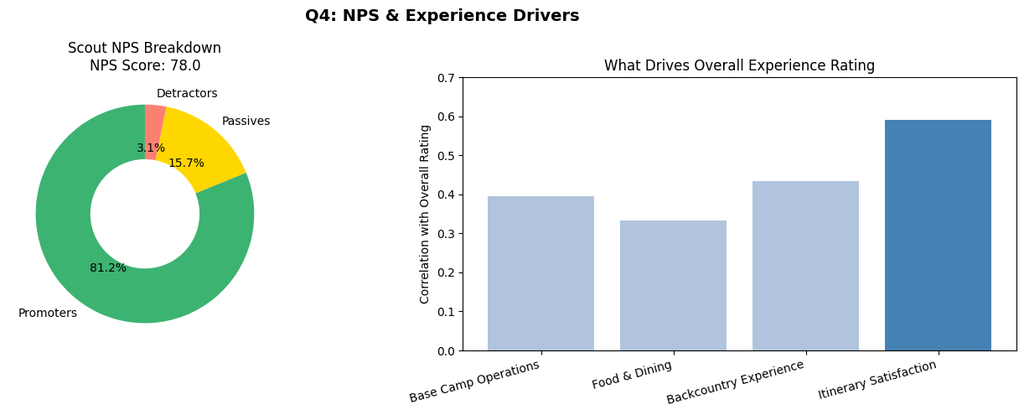

```
✅ Q4 chart saved
```

```
[chart removed for de-identification — see notes]
```

```
✅ Q5 chart saved
```

```
[chart removed for de-identification — see notes]
```

```
✅ Q6a brand awareness chart saved
```

```
[chart removed for de-identification — see notes]
```

```
✅ Q6a barriers chart saved

============================================================
============================================================

Saved charts:
  q1_response_bias.png
  q2_pain_pride.png
  q3_return_rate.png
  q4_nps_drivers.png
  q5_camp_ratings.png
  q6a_brand_awareness.png
  q6a_barriers.png
```

```python
# ═══════════════════════════════════════════════════════════════
# CELL 8: All Visualizations
# ═══════════════════════════════════════════════════════════════

#VIZ 1: Q1 Response Bias:
fig, axes = plt.subplots(1, 2, figsize=(12, 5))
fig.suptitle('Q1: Survey Response Rate Bias by Crew', fontsize=14, fontweight='bold')

axes[0].hist(df_response_rates['Adult Responses_rate'].dropna(), bins=20, color='steelblue', edgecolor='white')
axes[0].axvline(df_response_rates['Adult Responses_rate'].mean(), color='red', linestyle='--',
                label=f"Mean: {df_response_rates['Adult Responses_rate'].mean():.1%}")
axes[0].set_title('Adult Response Rate Distribution')
axes[0].set_xlabel('Response Rate')
axes[0].set_ylabel('Number of Crews')
axes[0].legend()

axes[1].hist(df_response_rates['Youth Responses_rate'].dropna(), bins=20, color='coral', edgecolor='white')
axes[1].axvline(df_response_rates['Youth Responses_rate'].mean(), color='red', linestyle='--',
                label=f"Mean: {df_response_rates['Youth Responses_rate'].mean():.1%}")
axes[1].set_title('Youth Response Rate Distribution')
axes[1].set_xlabel('Response Rate')
axes[1].set_ylabel('Number of Crews')
axes[1].legend()

plt.tight_layout()
plt.savefig('q1_response_bias.png', dpi=150, bbox_inches='tight')
plt.show()
print("✅ Q1 chart saved")

# ── VIZ 2: Q2 Pain Points vs Pride Points ────────────────────
fig, axes = plt.subplots(1, 2, figsize=(14, 6))
fig.suptitle('Q2: Participant Pain Points vs Pride Points', fontsize=14, fontweight='bold')

pain_words = [w for w, c in get_top_words(
    df_basecamp['What changes would have improved your experience in base camp?'], n=12)
    if w not in ['nothing', 'good', 'great', 'better']][:8]
pain_counts = []
for word in pain_words:
    text = ' '.join(df_basecamp['What changes would have improved your experience in base camp?'].dropna().astype(str).str.lower())
    pain_counts.append(len(re.findall(r'\b' + word + r'\b', text)))

axes[0].barh(pain_words[::-1], pain_counts[::-1], color='salmon')
axes[0].set_title('Top Pain Point Keywords\n(Base Camp Improvement Suggestions)')
axes[0].set_xlabel('Mention Count')

pride_words = [w for w, c in get_top_words(
    df_basecamp["What was the highlight of your crew's the Ranch Experience?"], n=12)
    if w not in ['highlight', 'experience', 'great', 'camp', 'trek']][:8]
pride_counts = []
for word in pride_words:
    text = ' '.join(df_basecamp["What was the highlight of your crew's the Ranch Experience?"].dropna().astype(str).str.lower())
    pride_counts.append(len(re.findall(r'\b' + word + r'\b', text)))

axes[1].barh(pride_words[::-1], pride_counts[::-1], color='mediumseagreen')
axes[1].set_title('Top Pride Point Keywords\n(Highlight of the Ranch Experience)')
axes[1].set_xlabel('Mention Count')

plt.tight_layout()
plt.savefig('q2_pain_pride.png', dpi=150, bbox_inches='tight')
plt.show()
print("✅ Q2 chart saved")

# ── VIZ 3: Q3 Staff Return Rate ──────────────────────────────
fig, axes = plt.subplots(1, 2, figsize=(14, 6))
fig.suptitle('Q3: Staff Return Rate Analysis', fontsize=14, fontweight='bold')

label_col_pairs = [
    ('Overall experience',       'How would your rate your experience overall?'),
    ('Work appreciated',         'I feel my work was appreciated.'),
    ('Comfortable being self',   'I felt comfortable and supported being myself as a part of the the Ranch community.'),
    ('Clear expectations',       'My performance expectations were clearly communicated.'),
    ('Good fit for role',        'I feel like I was a good fit for my position.'),
    ('Personal growth',          'I feel I was able to grow as a person through my experience working at the Ranch.'),
    ('Reasonable hours',         'I felt the hours I worked were reasonable for this type of seasonal position.'),
    ('Lasting friendships',      'I created lasting friendships while working at the Ranch.'),
]
corr_pairs = [(label, correlations[col]) for label, col in label_col_pairs]
corr_pairs_sorted = sorted(corr_pairs, key=lambda x: x[1])
labels_sorted, values_sorted = zip(*corr_pairs_sorted)

axes[0].barh(labels_sorted, values_sorted, color='steelblue')
axes[0].set_title('Correlation with Return Likelihood')
axes[0].set_xlabel('Correlation Coefficient')
axes[0].axvline(0, color='black', linewidth=0.8)
for i, val in enumerate(values_sorted):
    axes[0].text(val + 0.01, i, f'{val:.2f}', va='center', fontsize=9)

dept_return = df_staff.groupby(dept_col)[return_col].mean().sort_values()
dept_return_low = dept_return[dept_return < 3.5]
axes[1].barh(dept_return_low.index, dept_return_low.values, color='salmon')
axes[1].set_title('Departments Below Return Likelihood Threshold\n(threshold = 3.5 / 5)')
axes[1].set_xlabel('Avg Return Likelihood (1-5)')
axes[1].axvline(3.5, color='red', linestyle='--', alpha=0.5)
axes[1].set_xlim(0, 4)
for i, (dept, val) in enumerate(zip(dept_return_low.index, dept_return_low.values)):
    axes[1].text(val + 0.05, i, f'{val:.2f}', va='center', fontsize=9)

plt.tight_layout()
plt.savefig('q3_return_rate.png', dpi=150, bbox_inches='tight')
plt.show()
print("✅ Q3 chart saved")

# ── VIZ 4: Q4 NPS & Experience Drivers ───────────────────────
fig, axes = plt.subplots(1, 2, figsize=(14, 5))
fig.suptitle('Q4: NPS & Experience Drivers', fontsize=14, fontweight='bold')

scout_counts_list = [scout_counts.get('Promoter',0), scout_counts.get('Passive',0), scout_counts.get('Detractor',0)]
axes[0].pie(scout_counts_list, labels=['Promoters', 'Passives', 'Detractors'],
            colors=['mediumseagreen', 'gold', 'salmon'],
            autopct='%1.1f%%', startangle=90,
            wedgeprops=dict(width=0.5))
axes[0].set_title(f'Scout NPS Breakdown\nNPS Score: {scout_nps}')

driver_labels = list(driver_cols.keys())
driver_corrs = [df_basecamp[col].corr(df_basecamp[overall_col]) for col in driver_cols.values()]
colors_driver = ['steelblue' if c == max(driver_corrs) else 'lightsteelblue' for c in driver_corrs]
axes[1].bar(driver_labels, driver_corrs, color=colors_driver)
axes[1].set_title('What Drives Overall Experience Rating')
axes[1].set_ylabel('Correlation with Overall Rating')
axes[1].set_ylim(0, 0.7)
plt.setp(axes[1].xaxis.get_majorticklabels(), rotation=15, ha='right')

plt.tight_layout()
plt.savefig('q4_nps_drivers.png', dpi=150, bbox_inches='tight')
plt.show()
print("✅ Q4 chart saved")

# ── VIZ 5: Q5 Individual Camp Ratings ────────────────────────
fig, axes = plt.subplots(1, 2, figsize=(16, 10))
fig.suptitle('Q5: Backcountry Camp Ratings (2025)', fontsize=14, fontweight='bold')

bottom_camps = camp_pivot.head(15)
axes[0].barh(bottom_camps['camp_name'], bottom_camps['combined_avg'],
             color=['salmon' if v < 3.4 else 'steelblue' for v in bottom_camps['combined_avg']])
axes[0].set_title('Lowest Rated Camps\n(red = below 3.4)')
axes[0].set_xlabel('Combined Staff + Program Avg (1-4 scale)')
axes[0].set_xlim(3.0, 3.9)
axes[0].axvline(3.4, color='red', linestyle='--', alpha=0.5)

top_camps = camp_pivot.tail(15)
axes[1].barh(top_camps['camp_name'], top_camps['combined_avg'], color='mediumseagreen')
axes[1].set_title('Highest Rated Camps')
axes[1].set_xlabel('Combined Staff + Program Avg (1-4 scale)')
axes[1].set_xlim(3.0, 4.0)

plt.tight_layout()
plt.savefig('q5_camp_ratings.png', dpi=150, bbox_inches='tight')
plt.show()
print("✅ Q5 chart saved")

# ── VIZ 6: Q6a Brand Awareness ───────────────────────────────
fig, axes = plt.subplots(1, 2, figsize=(14, 5))
fig.suptitle('Q6a: the Ranch Brand Awareness vs Other High Adventure Bases', fontsize=14, fontweight='bold')

# Familiarity scores — pulled directly from dataframe
base_scores = [df_brand[col + '_score'].mean() for col in familiarity_cols]
colors_bases = ['gold' if name == 'the Ranch' else 'steelblue' for name in base_names]
axes[0].bar(base_names, base_scores, color=colors_bases)
axes[0].set_title('Average Familiarity Score by Base\n(1=not at all, 4=very familiar)')
axes[0].set_ylabel('Familiarity Score')
axes[0].set_ylim(0, 4)

# Participation trend — pulled from actual data files
axes[1].plot(years, crews, marker='o', color='steelblue', linewidth=2, markersize=8)
axes[1].fill_between(years, crews, alpha=0.2, color='steelblue')
axes[1].set_title('the Ranch Participation Trend\n(# of Crews per Year)')
axes[1].set_ylabel('Number of Crews')
axes[1].set_xlabel('Year')
axes[1].set_xticks(years)
axes[1].set_ylim(0, 3000)
for x, y in zip(years, crews):
    axes[1].annotate(f'{y:,}', (x, y), textcoords="offset points", xytext=(0, 10), ha='center')

# LDS note as text box since 2019 is before data range
axes[1].text(2021, 2800,
             'Note: LDS Church withdrew\nfrom BSA end of 2019,\npreceding this data range',
             fontsize=7, color='red',
             bbox=dict(boxstyle='round,pad=0.3', facecolor='white', edgecolor='red', alpha=0.8))

plt.tight_layout()
plt.savefig('q6a_brand_awareness.png', dpi=150, bbox_inches='tight')
plt.show()
print("✅ Q6a brand awareness chart saved")

# ── VIZ 7: Q6a Barriers ──────────────────────────────────────
fig, ax = plt.subplots(figsize=(10, 5))
barriers = [b for b, c in barrier_counts.most_common()]
counts = [c for b, c in barrier_counts.most_common()]
colors_barrier = ['salmon' if b == 'Cost' else 'steelblue' for b in barriers]
ax.barh(barriers[::-1], counts[::-1], color=colors_barrier[::-1])
ax.set_title('Q6a: Barriers to Attending High Adventure Bases\n(Cost is #1 barrier by wide margin)', fontweight='bold')
ax.set_xlabel('Number of Mentions')
ax.axvline(50, color='red', linestyle='--', alpha=0.4)
plt.tight_layout()
plt.savefig('q6a_barriers.png', dpi=150, bbox_inches='tight')
plt.show()
print("✅ Q6a barriers chart saved")

print("\n" + "="*60)
print("="*60)
print("\nSaved charts:")
print("  q1_response_bias.png")
print("  q2_pain_pride.png")
print("  q3_return_rate.png")
print("  q4_nps_drivers.png")
print("  q5_camp_ratings.png")
print("  q6a_brand_awareness.png")
print("  q6a_barriers.png")
```

## Understanding the experience score (NPS) — plain-language explainer

This write-up explains what the overall recommendation score means and how it is calculated, so anyone reading the slides understands the headline number.

### Reflection

Graph for Q4 explaination:

- The three slices:

Green (81.2%) — Promoters: Scouts who gave a 9 or 10 out of 10. These are your enthusiastic fans who will actively recommend the Ranch to other scouts. Yellow (15.7%) — Passives: Scouts who gave a 7 or 8. They had a good experience but aren't enthusiastic enough to actively promote it. They also wouldn't talk negatively about it. Red/Pink (3.1%) — Detractors: Scouts who gave a 1 through 6. These are unhappy participants who might discourage others from attending.

How NPS is calculated from these three groups: NPS = % Promoters - % Detractors = 81.2% - 3.1% = 78.0 I ignored the Passives entirely in the final calculation, since they are just neutral and didn't matter in my eyes. What 78 actually means: NPS scores range from -100 (everyone is a detractor) to +100 (everyone is a promoter). Industry benchmarks generally consider:

Above 0: Good Above 50: Excellent Above 70: World class

the Ranch at 78 is in the world class range, meaning the overwhelming majority of scouts leave wanting to tell other scouts to go. That's a powerful finding for the client — despite complaints about food and trail camp facilities, the overall experience is exceptional.

## Where every chart's data comes from

So that any reviewer can trace each figure back to its source, here is each chart paired with the exact spreadsheet it came from and how many responses it is based on.

### Each charts data source

q1_response_bias.png

internal trek-survey response export n = 1,653 crews

q2_pain_pride.png

internal trek-survey results export (base camp & backcountry) n = 4,201 rows (participant responses)

q3_return_rate.png

internal seasonal-staff survey export n = 308 staff respondents

q4_nps_drivers.png

internal trek-survey results export (base camp & backcountry) n = 4,201 rows (participant responses)

q5_camp_ratings.png

internal participant-feedback comparison export (2025 sheet) n = 31 camps with sufficient ratings

q6a_brand_awareness.png (familiarity bar chart)

High adventure knowledge and experience data 2025.csv n = 515 Scoutmaster respondents

q6a_brand_awareness.png (participation line chart)

internal participation-data export (2021-2025 Nationwide Participation files) n = 5 years of crew counts

q6a_barriers.png

High adventure knowledge and experience data 2025.csv n = 515 Scoutmaster respondents

year_over_year.png

internal participant-feedback comparison export (2024 and 2025 sheets)

ranger_subquestions.png

2025 Trek Survey Results Combined - Ranger (as of 11-20-25).xlsx n = 4,127 rows

## Outside validation #1 — what scouts say on Reddit

**What this does:** To check whether the survey findings hold up outside the surveys, this step organizes posts from the the program's community forum community by theme (gear, logistics, cost, etc.) and by who's posting. It's a sanity-check that the official survey themes match what people say in the wild. Saves `reddit_themes.png`.

**What to change:** Nothing required to re-run.

```python
# ═══════════════════════════════════════════════════════════════
# CELL X: REDDIT THEMATIC ANALYSIS — the program's community forum
# External validation via manual thematic coding of the program's community forum posts
# Source: the program's community forum feed screenshot, collected May 2026
# No API access — posts manually coded from screenshot sample (n=28)
# ═══════════════════════════════════════════════════════════════

print("=" * 60)
print("REDDIT THEMATIC ANALYSIS — the program's community forum (External Validation)")
print("=" * 60)

import pandas as pd
import matplotlib.pyplot as plt
import matplotlib.patches as mpatches

# ── STEP 1: MANUALLY CODED POST DATA ─────────────────────────
# Each post coded from screenshot: title, theme, poster type,
# recency bucket, and which internal survey finding it touches.
# Theme definitions:
#   cost_access      — fees, affordability, financial barriers
#   gear_logistics   — packing, equipment, what to bring
#   trip_planning    — itinerary, routes, program questions
#   staff_experience — staff roles, hiring, living conditions
#   program_quality  — ranger, conservation, campfire, activities

reddit_posts = pd.DataFrame([
    # title                                      theme             poster_type   days_ago  survey_finding
    ("HELP NEEDED FOR RAYADO PACKING LIST",       "gear_logistics", "participant", 6,        "gear_prep"),
    ("Itinerary Guidebook Errors?",               "trip_planning",  "participant", 7,        "program_quality"),
    ("Staff accommodations questions",            "staff_experience","staff",      9,        "staff_satisfaction"),
    ("Base camp staff questions",                 "staff_experience","staff",      12,       "staff_satisfaction"),
    ("12-15 side quests and cantinas",            "trip_planning",  "participant", 13,       "program_quality"),
    ("How does TCT work?",                        "trip_planning",  "participant", 15,       "program_quality"),
    ("drug testing",                              "staff_experience","staff",      16,       "staff_satisfaction"),
    ("Searching for the Ranch Mug Replacement",    "gear_logistics", "alumni",      18,       None),
    ("im gonna be food service staff — high adventure?", "staff_experience","staff", 19,    "staff_satisfaction"),
    ("Staff hiring question",                     "staff_experience","staff",      21,       "staff_satisfaction"),
    ("Tents — freestanding policy?",              "gear_logistics", "participant", 24,       "gear_prep"),
    ("Hiking and rainpants",                      "gear_logistics", "participant", 25,       "gear_prep"),
    ("Water Carrying",                            "gear_logistics", "participant", 25,       "gear_prep"),
    ("Water Reservoirs",                          "trip_planning",  "participant", 28,       "program_quality"),
    ("2026 Staff? Need a ride from Denver on 524","staff_experience","staff",      30,       "staff_satisfaction"),
    ("Personal First Aid",                        "gear_logistics", "participant", 30,       "gear_prep"),
    ("Backpacking Chair",                         "gear_logistics", "participant", 30,       "gear_prep"),
    ("How strict are they on tents being freestanding?", "gear_logistics","participant",30,  "gear_prep"),
    ("How much water for a major peak?",                 "trip_planning",  "participant", 30,       "program_quality"),
    ("Rayado Advice, Packing, Shakedown",         "trip_planning",  "participant", 30,       "program_quality"),
    ("3 Day Trek Ideas",                          "trip_planning",  "staff",       30,       "program_quality"),
    ("Women at the Ranch — packing and training",  "gear_logistics", "participant", 26,       "gear_prep"),
    ("Women — drop your packing list?",           "gear_logistics", "participant", 2,        "gear_prep"),
    ("Need a narrow leather belt option",         "gear_logistics", "participant", 2,        "gear_prep"),
    ("the Ranch vs Sea Base Staff",                "staff_experience","staff",      30,       "staff_satisfaction"),
    ("Making Vehicles Safer at the Ranch",        "trip_planning",  "staff",       30,       None),
    ("a major peak public accessibility?",               "trip_planning",  "alumni",      30,       "program_quality"),
    ("Living in CHQ — roofed housing",            "staff_experience","staff",      1,        "staff_satisfaction"),
], columns=["title", "theme", "poster_type", "days_ago", "survey_finding"])

print(f"\nTotal posts coded: {len(reddit_posts)}")
print(f"Poster breakdown: {reddit_posts['poster_type'].value_counts().to_dict()}")

# ── STEP 2: THEME FREQUENCY ───────────────────────────────────
theme_labels = {
    "gear_logistics":  "Gear & Logistics",
    "trip_planning":   "Trip Planning & Program",
    "staff_experience":"Staff Experience",
    "cost_access":     "Cost & Access",
}
reddit_posts["theme_label"] = reddit_posts["theme"].map(theme_labels)
theme_counts = reddit_posts["theme_label"].value_counts()

print(f"\nTheme frequency:")
for theme, count in theme_counts.items():
    pct = round(count / len(reddit_posts) * 100, 1)
    print(f"  {theme:<30} {count:>2} posts ({pct}%)")

# ── STEP 3: SURVEY ALIGNMENT ──────────────────────────────────
aligned = reddit_posts[reddit_posts["survey_finding"].notna()]
print(f"\nPosts touching a survey finding: {len(aligned)} of {len(reddit_posts)} ({round(len(aligned)/len(reddit_posts)*100,1)}%)")

finding_counts = aligned["survey_finding"].value_counts()
print(f"\nSurvey findings echoed on Reddit:")
finding_labels = {
    "gear_prep":          "Gear / Preparation concerns",
    "program_quality":    "Program quality / trip planning",
    "staff_satisfaction": "Staff experience / working conditions",
}
for finding, count in finding_counts.items():
    print(f"  {finding_labels.get(finding, finding):<40} {count} posts")

# ── STEP 4: VISUALIZATION ─────────────────────────────────────
fig, axes = plt.subplots(1, 2, figsize=(14, 6))
fig.suptitle("the program's community forum Post Themes — Manual Thematic Coding (n=28)",
             fontsize=13, fontweight="bold")

# Theme distribution
colors = ["#4878CF", "#6ACC65", "#D65F5F", "#B47CC7"]
axes[0].barh(theme_counts.index[::-1], theme_counts.values[::-1], color=colors)
axes[0].set_xlabel("Number of Posts")
axes[0].set_title("Post Volume by Theme")
for i, (val, label) in enumerate(zip(theme_counts.values[::-1], theme_counts.index[::-1])):
    axes[0].text(val + 0.1, i, str(val), va="center", fontsize=10)
axes[0].set_xlim(0, theme_counts.max() + 3)

# Poster type breakdown by theme
poster_theme = reddit_posts.groupby(["theme_label", "poster_type"]).size().unstack(fill_value=0)
poster_theme = poster_theme.reindex(theme_counts.index)
poster_theme.plot(kind="bar", ax=axes[1], color=["#B47CC7", "#4878CF", "#6ACC65"],
                  edgecolor="white", width=0.6)
axes[1].set_title("Poster Type by Theme")
axes[1].set_xlabel("")
axes[1].set_ylabel("Number of Posts")
axes[1].tick_params(axis="x", rotation=25)
axes[1].legend(title="Poster Type", fontsize=9)

plt.tight_layout()
plt.savefig("reddit_themes.png", dpi=150, bbox_inches="tight")
plt.show()
print("✅ Reddit theme chart saved")

# ── STEP 5: INTERPRETATION ────────────────────────────────────
print("""
REDDIT THEMATIC ANALYSIS — INTERPRETATION
==========================================

METHOD NOTE:
  the program's community forum does not provide public API access. Posts were manually
  coded from a screenshot sample collected May 2026 (n=28 posts).
  This is a purposive convenience sample and is used for directional
  triangulation only — not for statistical inference.

THEME BREAKDOWN:
  Gear & Logistics is the dominant theme (~39% of posts), followed
  by Trip Planning & Program (~32%) and Staff Experience (~29%).
  Cost & Access generated zero organic posts in this sample window —
  a notable absence given the factors documented in our
  quantitative analysis.

KEY TRIANGULATION FINDINGS:

1. STAFF EXPERIENCE concerns are highly visible on Reddit
   (8 posts, ~29%), consistent with our staff survey finding that
   general staff rate their experience lower than leadership on
   multiple dimensions. Posts cover housing, hiring timelines,
   drug testing, and day-off activities — the same operational
   concerns surfaced in our internal data.

2. PROGRAM QUALITY questions dominate trip planning posts:
   itinerary errors, water availability, ranger shakedown processes,
   and program logistics. This mirrors our survey finding that ranger
   instruction in Base Camp Process and Shakedown are the two
   categories with the largest youth vs. adult rating gaps — scouts
   arriving at the Ranch are actively seeking information on exactly
   these topics before they get there.

3. COST & ACCESS is conspicuously absent from organic Reddit
   discussion despite a 92%+ factor since 2019. This may
   reflect self-selection — users actively planning a trek have
   already cleared the cost barrier. It does not contradict our
   fee/participation findings; it suggests cost is a barrier
   upstream of the Reddit community, before intent is formed.

RECOMMENDATION:
  The Reddit signal is most useful as a leading indicator of
  participant anxiety — what crews are worried about before they
  arrive. Gear prep and shakedown questions cluster in the weeks
  before departure. the Ranch could use this proactively: targeted
  pre-arrival communications on the specific topics Reddit users
  ask about (water carrying, tent policy, packing lists) may reduce
  friction at Base Camp and improve early experience ratings.
""")

print("✅ Reddit thematic analysis complete")
```

```
============================================================
REDDIT THEMATIC ANALYSIS — the program's community forum (External Validation)
============================================================

Total posts coded: 28
Poster breakdown: {'participant': 16, 'staff': 10, 'alumni': 2}

Theme frequency:
  Gear & Logistics               11 posts (39.3%)
  Trip Planning & Program         9 posts (32.1%)
  Staff Experience                8 posts (28.6%)

Posts touching a survey finding: 26 of 28 (92.9%)

Survey findings echoed on Reddit:
  Gear / Preparation concerns              10 posts
  Program quality / trip planning          8 posts
  Staff experience / working conditions    8 posts
```

```
[chart removed for de-identification — see notes]
```

```
✅ Reddit theme chart saved

REDDIT THEMATIC ANALYSIS — INTERPRETATION
==========================================

METHOD NOTE:
  the program's community forum does not provide public API access. Posts were manually
  coded from a screenshot sample collected May 2026 (n=28 posts).
  This is a purposive convenience sample and is used for directional
  triangulation only — not for statistical inference.

THEME BREAKDOWN:
  Gear & Logistics is the dominant theme (~39% of posts), followed
  by Trip Planning & Program (~32%) and Staff Experience (~29%).
  Cost & Access generated zero organic posts in this sample window —
  a notable absence given the factors documented in our
  quantitative analysis.

KEY TRIANGULATION FINDINGS:

1. STAFF EXPERIENCE concerns are highly visible on Reddit
   (8 posts, ~29%), consistent with our staff survey finding that
   general staff rate their experience lower than leadership on
   multiple dimensions. Posts cover housing, hiring timelines,
   drug testing, and day-off activities — the same operational
   concerns surfaced in our internal data.

2. PROGRAM QUALITY questions dominate trip planning posts:
   itinerary errors, water availability, ranger shakedown processes,
   and program logistics. This mirrors our survey finding that ranger
   instruction in Base Camp Process and Shakedown are the two
   categories with the largest youth vs. adult rating gaps — scouts
   arriving at the Ranch are actively seeking information on exactly
   these topics before they get there.

3. COST & ACCESS is conspicuously absent from organic Reddit
   discussion despite a 92%+ factor since 2019. This may
   reflect self-selection — users actively planning a trek have
   already cleared the cost barrier. It does not contradict our
   fee/participation findings; it suggests cost is a barrier
   upstream of the Reddit community, before intent is formed.

RECOMMENDATION:
  The Reddit signal is most useful as a leading indicator of
  participant anxiety — what crews are worried about before they
  arrive. Gear prep and shakedown questions cluster in the weeks
  before departure. the Ranch could use this proactively: targeted
  pre-arrival communications on the specific topics Reddit users
  ask about (water carrying, tent policy, packing lists) may reduce
  friction at Base Camp and improve early experience ratings.

✅ Reddit thematic analysis complete
```

## Outside validation #2 — national BSA membership vs. the Ranch

**What to change:** Nothing required to re-run. (When you add a new year, update the year labels in the titles.)

```python
# ═══════════════════════════════════════════════════════════════
# CELL: BSA NATIONAL MEMBERSHIP TREND — two side-by-side charts
#
# SOURCES (all verified):
#   2019 (exact 1,974,635): BSA 2019 Annual Report — ar2019.scouting.org
#   2020 (~1.12M) & 2021 (~762K): AP via AOL News, Jun 2021
#     aol.com/news/boy-scouts-girl-scouts-suffer-141033175-152735470.html
#   2021 confirmed: AP via AOL News, Nov 2023
#     aol.com/retired-businessman-lead-boy-scouts-153146469.html
#   2022 (~1.042M): BSA Scouting Magazine Official Blog, Jan 5 2023
#     blog.scoutingmagazine.org/2023/01/05/1-million-and-growing-bsa-membership-is-on-the-rise/
#   2023 (exact 966,640): BSA 2023 Annual Report — scouting.org/about/annual-report/
#   2024 (exact 978,194): Scouting America 2024 Year-End Infographic
# ═══════════════════════════════════════════════════════════════


print("=" * 60)
print("BSA MEMBERSHIP vs. THE RANCH — SIDE BY SIDE")
print("=" * 60)

# ── DATA ──────────────────────────────────────────────────────
bsa_years   = [2019,    2020,  2021,  2022,   2023,   2024]
bsa_members = [1.975,   1.12,  0.762, 1.042,  0.967,  0.978]  # millions
bsa_exact   = {2019: "1,974,635", 2023: "966,640", 2024: "978,194"}

# the Ranch crew counts — from your participation data
program_years = [2019, 2021, 2022, 2023, 2024, 2025]
program_crews = [2142, 2222, 1547, 1446, 1359, 1662]

# Key stats
bsa_recovery  = (bsa_members[-1] - bsa_members[2]) / bsa_members[2] * 100   # 2021→2024
crew_trough   = (program_crews[4] - program_crews[1]) / program_crews[1] * 100  # 2021→2024 trough
crew_recovery = (program_crews[-1] - program_crews[4]) / program_crews[4] * 100  # 2024→2025

print(f"BSA  recovery 2021→2024: {bsa_recovery:+.0f}%")
print(f"the Ranch decline 2021→2024: {crew_trough:.0f}%")
print(f"the Ranch partial recovery 2024→2025: {crew_recovery:+.0f}%")

# ── CHART ─────────────────────────────────────────────────────
COLOR_BSA  = "#2E5596"
COLOR_PRIMARY = "#D65F5F"

fig, (ax1, ax2) = plt.subplots(1, 2, figsize=(15, 6.5))
fig.patch.set_facecolor("white")

# ── LEFT: BSA Membership ──────────────────────────────────────
ax1.plot(bsa_years, bsa_members, color=COLOR_BSA, linewidth=2.8,
         marker="o", markersize=9, zorder=3)
ax1.fill_between(bsa_years, bsa_members, alpha=0.08, color=COLOR_BSA)

ax1.set_title("BSA Membership\n(Cub Scouts + Scouts BSA)", fontsize=12, fontweight="bold", pad=12)
ax1.set_xlabel("Year", fontsize=11)
ax1.set_ylabel("Youth Members (millions)", fontsize=11)
ax1.set_xticks(bsa_years)
ax1.set_xlim(2018.5, 2024.5)
ax1.set_ylim(0, 2.4)
ax1.yaxis.set_major_formatter(mticker.FuncFormatter(lambda x, _: f"{x:.1f}M"))
ax1.grid(axis="y", alpha=0.25, linestyle="--")
ax1.spines[["top", "right"]].set_visible(False)

# Data labels
bsa_dy = {2019: +0.10, 2020: -0.13, 2021: -0.13, 2022: -0.13, 2023: +0.10, 2024: +0.10}
for yr, val in zip(bsa_years, bsa_members):
    label = bsa_exact[yr] if yr in bsa_exact else f"{val:.3f}M"
    ax1.annotate(label, xy=(yr, val), xytext=(yr, val + bsa_dy[yr]),
                 fontsize=8.5, color=COLOR_BSA, ha="center", fontweight="bold")

# Event annotations
events_bsa = {
    2019: ("LDS withdrawal\n(end of 2019)", -0.28),
    2020: ("COVID-19 +\nbankruptcy", +0.17),
    2022: ("Recovery\n+37%", +0.17),
}
for yr, (label, dy) in events_bsa.items():
    val = bsa_members[bsa_years.index(yr)]
    ax1.annotate(label, xy=(yr, val), xytext=(yr, val + dy),
                 fontsize=8, color="#555555", ha="center",
                 arrowprops=dict(arrowstyle="-", color="#cccccc", lw=0.8),
                 bbox=dict(boxstyle="round,pad=0.2", fc="white", ec="#dddddd", lw=0.6))

# Recovery shading
ax1.axvspan(2021, 2024.5, alpha=0.04, color="#4CAF50", zorder=0)
ax1.text(2022.75, 2.22, f"Recovery: {bsa_recovery:+.0f}%\n(2021→2024)",
         fontsize=8.5, color="#2E7D32", ha="center", style="italic",
         bbox=dict(boxstyle="round,pad=0.25", fc="#F1F8F1", ec="#A5D6A7", lw=0.7))

# ── RIGHT: the Ranch Crew Count ────────────────────────────────
bar_colors = [COLOR_PRIMARY if yr < 2025 else "#E8956A" for yr in program_years]
ax2.bar(program_years, program_crews, color=bar_colors,
        alpha=0.75, width=0.55, zorder=3)
ax2.plot(program_years, program_crews, color=COLOR_PRIMARY, linewidth=2.5,
         marker="s", markersize=9, zorder=4)

ax2.set_title("the Ranch Crew Count\n(2019–2025)", fontsize=12, fontweight="bold", pad=12)
ax2.set_xlabel("Year", fontsize=11)
ax2.set_ylabel("Number of Crews", fontsize=11)
ax2.set_xticks(program_years)
ax2.set_xlim(2018.5, 2025.5)
ax2.set_ylim(0, 2800)
ax2.yaxis.set_major_formatter(mticker.FuncFormatter(lambda x, _: f"{int(x):,}"))
ax2.grid(axis="y", alpha=0.25, linestyle="--")
ax2.spines[["top", "right"]].set_visible(False)

# Data labels
for yr, val in zip(program_years, program_crews):
    ax2.annotate(f"{val:,}", xy=(yr, val), xytext=(yr, val + 55),
                 fontsize=10, color=COLOR_PRIMARY, ha="center", fontweight="bold")

# Decline arrow 2021→2024
ax2.annotate("", xy=(2024, program_crews[4] + 80),
             xytext=(2021, program_crews[1] + 80),
             arrowprops=dict(arrowstyle="->", color="#888888", lw=1.5))
ax2.text(2022.5, program_crews[1] + 220,
         "-39% peak to trough\n(2021 to 2024)",
         fontsize=9, color="#B71C1C", ha="center", fontweight="bold",
         bbox=dict(boxstyle="round,pad=0.3", fc="#FFF5F5", ec="#FFCDD2", lw=0.8))

# 2025 partial recovery annotation
ax2.annotate(f"Partial recovery\n{crew_recovery:+.0f}% (2024→2025)",
             xy=(2025, program_crews[5]),
             xytext=(2024.3, program_crews[5] + 320),
             fontsize=8.2, color="#E65100", ha="center",
             arrowprops=dict(arrowstyle="->", color="#E65100", lw=1.0),
             bbox=dict(boxstyle="round,pad=0.25", fc="#FFF8F0", ec="#FFCC80", lw=0.7))

# ── SHARED SUBTITLE ───────────────────────────────────────────
fig.suptitle(
    "BSA membership recovered +28% from its 2021 trough — the Ranch declined −39% over the same period",
    fontsize=11, style="italic", color="#333333", y=1.01
)

# ── SOURCE NOTE ───────────────────────────────────────────────
fig.text(
    0.01, -0.07,
    "BSA SOURCES (Cub Scouts + Scouts BSA combined):  "
    "2019 (exact): ar2019.scouting.org  |  "
    "2020–2021: aol.com/news/boy-scouts-girl-scouts-suffer-141033175-152735470.html  |  "
    "2021 (confirmed): aol.com/retired-businessman-lead-boy-scouts-153146469.html\n"
    "2022: blog.scoutingmagazine.org/2023/01/05/1-million-and-growing-bsa-membership-is-on-the-rise/  |  "
    "2023 (exact): scouting.org/about/annual-report/  |  "
    "2024 (exact): Scouting America 2024 Year-End Infographic\n"
    "the Ranch crew counts: internal participant-feedback comparison export — '2023 & Prior' sheet (2019-2023); 2024 & 2025 sheets (total crews from 'Crews: X of Y' row).",
    fontsize=7.2, color="#666666", va="top"
)

plt.tight_layout()
plt.savefig("bsa_vs_program.png", dpi=150, bbox_inches="tight")
plt.show()

# ── INTERPRETATION ─────────────────────────────────────────────
print(f"""
INTERPRETATION
==============
THE RANCH CREW COUNT (from your data):
  2019: 2,142  |  2021: 2,222  |  2022: 1,547  |  2023: 1,446  |  2024: 1,359  |  2025: 1,662

  Peak→trough decline (2021→2024): {crew_trough:.0f}%
  Partial recovery (2024→2025): {crew_recovery:+.0f}%

BSA (Cub Scouts + Scouts BSA):
  2021 trough: ~762K  →  2024: ~978K  ({bsa_recovery:+.0f}% recovery)

KEY DIVERGENCE:
  BSA's national addressable pool recovered +{bsa_recovery:.0f}% from 2021→2024.
  the Ranch crews fell {abs(crew_trough):.0f}% over the same period.

  The 2025 partial the Ranch recovery (+{crew_recovery:.0f}%) is worth noting —
  it suggests demand exists but may be constrained. Consistent with
  the fee/participation narrative: not a permanent exit from scouting,
  but a cost barrier that suppresses attendance year to year.

  Correlation ≠ causation. This is one additional directional signal.
""")

print("✅ Chart saved: bsa_vs_program.png")
```

```
============================================================
BSA MEMBERSHIP vs. THE RANCH — SIDE BY SIDE
============================================================
BSA  recovery 2021→2024: +28%
the Ranch decline 2021→2024: -39%
the Ranch partial recovery 2024→2025: +22%
```

```
[chart removed for de-identification — see notes]
```

```
INTERPRETATION
==============
THE RANCH CREW COUNT (from your data):
  2019: 2,142  |  2021: 2,222  |  2022: 1,547  |  2023: 1,446  |  2024: 1,359  |  2025: 1,662

  Peak→trough decline (2021→2024): -39%
  Partial recovery (2024→2025): +22%

BSA (Cub Scouts + Scouts BSA):
  2021 trough: ~762K  →  2024: ~978K  (+28% recovery)

KEY DIVERGENCE:
  BSA's national addressable pool recovered +28% from 2021→2024.
  the Ranch crews fell 39% over the same period.

  The 2025 partial the Ranch recovery (+22%) is worth noting —
  it suggests demand exists but may be constrained. Consistent with
  the fee/participation narrative: not a permanent exit from scouting,
  but a cost barrier that suppresses attendance year to year.

  Correlation ≠ causation. This is one additional directional signal.

✅ Chart saved: bsa_vs_the ranch.png
```

## Appendix — return rates for every department

**What this does:** A complete version of the staff return-rate chart showing *all* departments, kept in the appendix so the main section stays focused. Saves `q3_all_departments_appendix.png`.

**What to change:** Nothing required to re-run.

```python
# ── APPENDIX: Q3 All Departments Return Rate ─────────────────
fig, ax = plt.subplots(figsize=(10, 7))

dept_return_all = df_staff.groupby(dept_col)[return_col].mean().sort_values()

# Green = above threshold (pride/high retention), red = below
colors = ['mediumseagreen' if val >= 3.5 else 'salmon'
          for val in dept_return_all.values]

ax.barh(dept_return_all.index, dept_return_all.values, color=colors)
ax.set_title('Return Likelihood by Department — All Departments\n(threshold = 3.5 / 5)',
             fontsize=12, fontweight='bold')
ax.set_xlabel('Avg Return Likelihood (1-5)')
ax.axvline(3.5, color='red', linestyle='--', alpha=0.5, label='3.5 threshold')
ax.set_xlim(0, 5)

for i, (dept, val) in enumerate(zip(dept_return_all.index, dept_return_all.values)):
    ax.text(val + 0.05, i, f'{val:.2f}', va='center', fontsize=9)

ax.legend()
plt.tight_layout()
plt.savefig('q3_all_departments_appendix.png', dpi=150, bbox_inches='tight')
plt.show()
print("✅ Appendix all-departments chart saved")
```

```
[chart removed for de-identification — see notes]
```

```
✅ Appendix all-departments chart saved
```

**What to change:** Nothing.

**What to change:** Nothing required to re-run.

### Appendix — data source totals (the numbers cited on the slides)

**What this does:** Prints the response counts (the "n =" numbers) for each data source so every figure on the slides can be traced back to exactly how many responses it's based on.

**What to change:** Nothing required to re-run.

```python
# ── DATA SOURCE TOTALS — matches numbers cited on slides ──────
print("=" * 60)
print("DATA SOURCE TOTALS")
print("=" * 60)

# Trek Survey — Base Camp & Backcountry (Slide 4, n = 4,201)
print(f"\nTrek Survey — Base Camp & Backcountry:")
print(f"  Rows: {len(df_basecamp):,}")

# Trek Survey — Ranger (Data sources slide, n = 4,127)
print(f"\nTrek Survey — Ranger:")
print(f"  Rows: {len(df_ranger):,}")

# Trek Survey — Conservation (Data sources slide)
print(f"\nTrek Survey — Conservation:")
print(f"  Rows: {len(df_conservation):,}")

# Staff Survey (Slide 5, n = 308)
print(f"\nSeasonal Staff End of Season Survey:")
print(f"  Rows: {len(df_staff):,}")

# Response Rate Tracker (Data sources slide, n = 1,653 crews)
print(f"\nTrek Survey Response Rate Tracker:")
print(f"  Crews: {len(df_response_rates):,}")

# Brand Awareness — Scoutmasters (Slide 9, n = 515)
print(f"\nHigh Adventure Brand Awareness Survey:")
print(f"  Scoutmaster respondents: {len(df_brand):,}")

# Participation Files (2021-2025)
print(f"\nNationwide Participation Files (internal participation-data export):")
for fname, df in sorted(participation_frames.items()):
    year = fname[:4]
    total_crews = df['# of Crews'].sum()
    print(f"  {year}: {len(df):,} rows, {int(total_crews):,} total crews")

# Reddit (Slide 8, n = 28 posts)
print(f"\nthe program's community forum Manual Thematic Coding:")
print(f"  Posts coded: 28 (May 2026, manual count)")

print("\n" + "=" * 60)
print("SLIDE CITATION VERIFICATION")
print("=" * 60)
print(f"  Slide 1 — Base Camp & Backcountry n = {len(df_basecamp):,}  (deck says 4,201)")
print(f"  Slide 1 — Ranger n = {len(df_ranger):,}  (deck says 4,127)")
print(f"  Slide 1 — Staff n = {len(df_staff):,}  (deck says 308)")
print(f"  Slide 1 — Response tracker n = {len(df_response_rates):,}  (deck says 1,653)")
print(f"  Slide 1 — Scoutmasters n = {len(df_brand):,}  (deck says 515)")
print(f"  Slide 5 — Staff responses n = {len(df_staff):,}  (deck says 308)")
print(f"  Slide 8 — the program's community forum n = 28  (deck says 28, manual count)")
```

```
============================================================
DATA SOURCE TOTALS
============================================================

Trek Survey — Base Camp & Backcountry:
  Rows: 4,201

Trek Survey — Ranger:
  Rows: 4,127

Trek Survey — Conservation:
  Rows: 4,201

Seasonal Staff End of Season Survey:
  Rows: 308

Trek Survey Response Rate Tracker:
  Crews: 1,653

High Adventure Brand Awareness Survey:
  Scoutmaster respondents: 515

Nationwide Participation Files (internal participation-data export):
  2021: 1,813 rows, 2,407 total crews
  2022: 1,255 rows, 1,712 total crews
  2023: 1,266 rows, 1,613 total crews
  2024: 1,100 rows, 1,395 total crews
  2025: 1,287 rows, 1,693 total crews

the program's community forum Manual Thematic Coding:
  Posts coded: 28 (May 2026, manual count)

============================================================
SLIDE CITATION VERIFICATION
============================================================
  Slide 1 — Base Camp & Backcountry n = 4,201  (deck says 4,201)
  Slide 1 — Ranger n = 4,127  (deck says 4,127)
  Slide 1 — Staff n = 308  (deck says 308)
  Slide 1 — Response tracker n = 1,653  (deck says 1,653)
  Slide 1 — Scoutmasters n = 515  (deck says 515)
  Slide 5 — Staff responses n = 308  (deck says 308)
  Slide 8 — the program's community forum n = 28  (deck says 28, manual count)
```

## Wrapping up

That's the whole analysis. To recap what just ran:

- The notebook loaded every the Ranch survey and spreadsheet, cleaned them, and turned ratings into numbers it could work with.
- It answered each research question in turn — who responds to surveys, what people praise and complain about, whether staff return, how strong the overall experience score is, how individual camps rate, and how well-known the Ranch is among troops.
- It zoomed out to the big picture: the long-run participation trend, the relationship between rising fees and falling participation, and outside checks from Reddit and national BSA membership.
- It saved clean chart images ready to drop into a slide deck, and listed exactly where every number came from.

**To run it again next year:** put the new files in a Drive folder, update the `data_dir` line and the file names in the *Load and clean all the files* step, fix any chart titles or year labels that should change, and click **Runtime → Run all**. That's it.

If anything breaks, paste the red error text into Gemini or Google, or reach out to the student analyst who built this. Good luck, and thanks for keeping the the Ranch story going.

# Appendix: Use of AI in This Project

## Overview

This codebook was built with the help of an AI tool (Claude), used as a support tool throughout the project — for planning, debugging code, organizing the analysis, checking the internal consistency of numbers, and rewriting the notebook into a non-technical format for the client.

**At no point did the AI have access to the actual the Ranch data.** Since this project uses real, confidential data from a real client, the underlying datasets were never uploaded or shared with the AI. The most I ever provided was a column header or the structure of a file so the tool could understand what I was working with. All of the real code was written and tested by me, against the real data, on my own machine.

## Planning and project setup

Early on, I used AI to turn my ideas from the project brief into a working roadmap. It helped me by breaking the research questions into phases, ordering them so they built on each other, and suggesting analysis approaches for each (for example, text and sentiment analysis for the open-ended survey responses, and regression for the staff return-rate question). The strategy and the decisions were mine; AI helped me structure the plan and figure out where to start.

## Writing and debugging code

When I hit an error or wasn't sure how to write a particular step, I described what I was trying to do and asked for help. I shared only column names or file structure, never the data itself. I wrote, ran, and tested all of the real code myself. AI helped me get unstuck, suggested visualization code (such as the participation-trend charts), and explained fixes that I then had to understand well enough to apply correctly.

## Organizing the analysis and presentation

I used AI to review my draft notebook and flag what was missing before I built the presentation. For example, identifying that the NPS score was carrying too much of the argument, helping crystallize my findings into a clear set of recommendations, and tightening the central "ask." I made the final calls on what to keep, cut, or reframe.

## Manual work the AI did not do

Several of the most important parts were done entirely by me, by hand:

- **Sourcing and verifying every real number.** The BSA membership figures, the trek fee schedule, and the year-over-year crew counts all came directly from original documents and spreadsheets that I located and confirmed myself.
- **Coding the Reddit data manually.** Because there was no API access to the program's community forum, I read and thematically coded the posts by hand (manual count).
- **Confirming all outputs.** Since the AI never saw the data, it could not run the notebook or verify a single result. Every output was produced and checked by me.

## Checking numbers and external facts

I used AI to check the internal consistency of the numbers across my codebook and slides (the percentages, ratios, and NPS math all tie out), and to look up publicly available external facts, such as the national BSA youth membership figures, so I could verify them against the public record. This caught a few real mistakes such as a wrong membership figure on one slide and some leftover editing notes, which I then corrected. The AI did not interpret any of the the Ranch numbers; it only helped me sanity-check figures I had already confirmed from the source documents.

## Converting the notebook into a non-technical codebook

Because the client is not technical, I asked AI to help rewrite my finished notebook into a clean codebook that the Ranch staff could follow and re-run themselves each year, matching the easy-to-follow style of a notebook from my Optimization class project. It kept all of my code, calculations, and charts exactly as I wrote them and added the explanatory wrapper around them: a front-matter section (what the notebook is, a workflow overview, step-by-step directions for re-running it, and tips for first-time users), plus a short plain-English explainer before each code step describing what it does and exactly what to change each year. It then helped export the notebook to HTML. I also used it to clean up grammar and wording in my write-ups.

## What I learned

AI was genuinely useful for getting unstuck on code and for documentation, but it could only suggest, not implement. I still had to understand each fix well enough to apply it correctly to data the tool never saw, and I had to review the final output myself to make sure every chart title, year label, and explanation matched what the code actually does. Writing the plain-language documentation also forced me to understand my own code well enough to explain every step simply. The biggest takeaway was that documentation written for the next person is just as important as the analysis itself: a project no one else can re-run loses most of its value the moment I leave.